# The TEACH Intervention for Youth with Childhood-Onset Lupus

Research Case Study for Michigan State University course OST 597 (Biomedical Research Structure and Methods)

Steven J. Pierce

pierces1@msu.edu

Michigan State University, Center for Statistical Training and Consulting

Natoshia R. Cunningham

Michigan State University, Department of Family Medicine

Andrea Knight

University of Toronto, Temerty Faculty of Medicine

2026-03-30

## Preface

- Presentation is based on a forthcoming paper.<sup>[1]</sup>
- Slides are available from the link at bottom of screen.
- Study was approved by MSU IRB (STUDY00003882).

**Funding**

All phases of this study were supported by a Childhood Arthritis and Rheumatology Research Alliance-Arthritis Foundation Transdisciplinary Research Grant (PI: Natoshia R. Cunningham).

## Contributors

- **Natoshia R. Cunningham**
- Thea Senger-Carpenter
- Jocelyn Zuckerman
- Michelle Adler
- Mallet R. Reid
- Ashley Danguecan
- Luana Flores Pereira
- Sarah I. Mossad
- Samantha L. Ely
- Khalid Abulaban
- Elizabeth A. Kessler
- Natalie Rosenwasser
- Tamar B. Rubinstein
- Ekemini A. Ogbu
- Emily A. Smitherman
- Alaina Miller
- Taylor Abounader
- Elizabeth Ross
- Livie Timmerman
- Dhriti Sharma
- Jennifer N. Stinson
- Stacy Allen
- Kabita Nanda
- Tala El Tal
- Deborah M. Levy
- Linda T. Hiraki
- Hermine I. Brunner
- Mathew Reeves
- Steven J. Pierce
- **Andrea Knight**

**Bold = Principal investigators.**

# Introduction

## Childhood-Onset Systemic Lupus Erythematosus (cSLE)

- A chronic, multisystemic, autoimmune disease.
- Higher risk for depressive, fatigue, and pain symptoms, which may lower health-related quality of life (HR-QOL).
- More often affects female and Asian, Native American, and Black youth.
- Black youth may get less help managing comorbid symptoms than White peers.

## Cognitive Behavioral Therapy (CBT)

- Effective for managing depression, fatigue, and pain in youth with other chronic illnesses and in *adults* with lupus.
- Prior studies on CBT for *youth* with lupus:
  - One failed to find clinically significant effects on pain, affect, & quality of life.
  - Treatment and Education Approach for Childhood-Onset Lupus (TEACH) program had promising results but needed refinements.

## TEACH: Initial Pilot Study

- A tailored, CBT program delivered via 6 weekly sessions.
- Targeted depressive, fatigue, & pain symptoms.
- High retention rate (82.4%).
- Reduced depressive and fatigue symptoms.
- Marginal reductions in pain and anxiety.

## TEACH: Initial Lessons Learned

- Patients wanted a remote delivery option.
- Need to engage patients in refining the intervention.
- Need to better address pain & anxiety.
- Need to get stronger evidence of efficacy.

## Current Study

- Refined TEACH intervention for adolescents/young adults with cSLE.
  - Update program content per previous feedback.
  - Switch to remote delivery via video calls.
- Primary outcomes: feasibility & acceptability.

## Current Study (Continued)

Test efficacy of TEACH vs. TAU on …

**Secondary Outcomes**

- Depressive symptoms.
- Fatigue.
- Pain intensity.

**Exploratory Outcomes**

- Disease activity.
- Medication adherence.
- Anxiety symptoms.
- Health-related quality of life.

# Methods

## Research Design

| Arm | Longitudinal Event Pretest Week 0 | Longitudinal Event Allocation | Longitudinal Event Intervention | Longitudinal Event Posttest Week 8 |
| --- | --- | --- | --- | --- |
| TEACH | $O_1$ | $R$ | $X$ | $O_2$ |
| TAU | $O_1$ | $R$ |  | $O_2$ |

Note: $O_i$, observed data at time $i$; $R$, randomized; $X$, delivery of TEACH intervention (6 weeks).

- Preregistered at ClinicalTrials.gov (NCT04335643)

## Sites: Pediatric Rheumatology Clinics

**United States**

- Helen DeVos Children’s Hospital
- Cincinnati Children’s Hospital Medical Center
- Seattle Children’s Hospital
- Children’s Hospital at Montefiore
- University of Alabama

**Canada**

- The Hospital for Sick Children, Toronto

## Participants

**Inclusion Criteria**

- Age 12-22 years,
- cSLE diagnosis by age 18 yrs,
- Elevated symptoms:
  - Depressive: $60 \le T < 90$
  - Fatigue: $T \ge 60$
  - Pain: $\ge 3$
- English language proficiency.

**Exclusion Criteria**

- Other chronic medical conditions,
- Developmental delays or severe cognitive impairments,
- Untreated major psychiatric illness, or
- In treatment for depressive, fatigue, or pain symptoms.

## TEACH Intervention

- Advisory input from cSLE patients & caregivers.
- A tailored, CBT program, 6 weekly video calls.
- Delivered by 1 of 3 interventionists.
- Supporting online modules, caregiver involved for minors
- Still targets depressive, fatigue, & pain symptoms.
- Psychoeducation, behavioral, cognitive, & mindfulness strategies.

## Fidelity Assessment

- Fidelity is the degree to which an intervention is delivered as intended by its developers.
- Low fidelity may weaken intervention effects.
- Our team recorded all video sessions with patients.
- Evaluators scored fidelity of each session (0-100%) via standardized checklist.

**Tip**

**Average fidelity was 98%!**

## Random Assignment

- Eliminates selection bias & minimizes confounding.
- Enhances internal validity & causal inference.
- Simple random assignment:
  - Sets equal probability of being in each arm.
  - Works best in large samples.
  - Risks unequal sample sizes & distributions in small samples.

## Stratified Random Block Randomization

| Stratum | Country | Age Group |
| --- | --- | --- |
| 1 | United States | Adolescent (12-17 yrs) |
| 2 | United States | Young Adult (18-22 yrs) |
| 3 | Canada | Adolescent (12-17 yrs) |
| 4 | Canada | Young Adult (18-22 yrs) |

Note: Within stratum, 1:1 ratio for arms (random blocks, n = 4 or 8). Investigators were blind to randomization.

## Primary Outcome Measures

- Recruitment rate = (# consented)/(# approached)
  - Benchmark: > 65 %
- Retention rate = (# completed posttest)/(# randomized)
  - Benchmark: > 80%
- Qualitative interviews about TEACH acceptability

## Secondary Outcome Measures

- Depressive symptoms over past 2 weeks.
  - CDI-II (28 items) or BDI-II (21 items), $T$-scores.
- Fatigue over past week.
  - PROMIS PSF/ASF (10/8 items), $T$-scores.
- Pain intensity over past 2 weeks.
  - Pain Visual Analog Scale (VAS), scores 0-10.

## Exploratory Outcome Measures

- Anxiety for past 3 months
  - SCARED/SCAARED (41/44 items), $z$-scores.
- Disease activity
  - SLEDAI-2K, scores from 0-105 ($\ge 6$ shows active disease).
- Medication adherence over past month
  - Adapted from Medication Adherence Self-Report Inventory, 0-100%
  - Scores $\ge 80$% indicate adequate adherence.
- Pediatric health-related quality of life (HR-QOL)
  - PedsQL Quality of Life Inventory (child & caregiver)
  - PedsQL Rheumatology Module (child & caregiver)

## Other Measures

- Demographics: Age, sex, race, ethnicity, disease duration (months), education.
- Disease manifestations: Systemic Lupus International Collaborating Clinics (SLICC) classification.
- Adverse childhood experiences (ACEs, scores 0-9).

## Qualitative Analysis

- Grounded theory & thematic analytic framework.
- Interviews recorded & transcribed.
- Reviewed by 3 trained coders.
- Quotes coded into themes until saturation & consensus achieved.

## Quantitative Analysis

- Estimated recruitment and retention rates.
- Intent-to-treat (ITT) estimate of intervention effect on secondary & exploratory outcomes.
  - Use all randomized participants.
  - Stay in assigned arm regardless of non-compliance, missing data, etc.
  - Gold standard for testing efficacy in RCTs.

## Analysis of Covariance (ANCOVA)

[figure not shown]

## Imputing Missing Data via MICE

- Allowed retaining all cases as required for ITT analysis
- 55% of cases had at least one missing value.
- Imputation model used:
  - All focal predictors & covariates used in the (ANCOVA) model.
  - Binary indicator of post-assessment attendance.
  - Longitudinal relationships between pretest & posttest for each outcome.
  - Cross-sectional relationships among outcomes measured at the same time.
- Parameter estimates pooled across analyses of 55 imputed data sets.

# Results

## Sample Descriptives

- Country: 61% US, 39% CA
- Age: M = 16.5, SD = 2.1, 64% adolescent, 36% young adult
- Sex: 97% female, 3% male
- Race: 42% White, 25% Asian, 22% Black, 9% Other, 2% Missing
- Ethnicity: 77% Not Hispanic, 22% Hispanic, 2% Missing

## CONSORT Chart

[figure not shown]

**Primary Outcomes**

- Recruitment rate = 97/200 = 48.5% (benchmark: 65%)
- Retention rate = 59/64 = 92.2% (benchmark: 80%)
  - Unrelated: arm, country, age group, race, ethnicity, most pretest outcomes.
  - Related: pretest child rheumatology QOL, disease duration.

## Pretest Symptoms (Raw/Unimputed)

| Variable | TEACH M (SD) | TAU M (SD) |
| --- | --- | --- |
| Depressive Symptoms | 63.6 (12.0) | 64.4 (10.4) |
| Fatigue | 61.6 (8.5) | 60.1 (6.7) |
| Pain Intensity | 3.5 (2.0) | 4.0 (1.9) |
| Anxiety | 0.1 (1.1) | -0.1 (0.8) |

## Pretest cSLE-Related Factors (Raw/Unimputed)

| Variable | TEACH | TAU |
| --- | --- | --- |
| Months since diagnosis | *31 (1-192)* | *26 (0-178)* |
| No. of Medications | *2 (0-12)* | *2 (0-10)* |
| Medication Adherence | 83.7 (15.7) | 84.1 (19.2) |
| Disease Manifestations | 0.50 (0.75) | 0.53 (1.0) |
| Disease Activity | *5 (0-18)* | *2 (0-12)* |

Note: Italics: *median (range)*. Normal font: mean (SD)

## Primary Outcomes: Acceptability Themes

- Skills were logically connected & went “hand in hand”.
- Relaxation skills, pleasant activity planning, & activity pacing were helpful.
- There was immediate effect of using the skills taught.
- Relationship w/ interventionist motivated practicing skills.
- Symptom severity & busy schedules were barriers.
- Virtual format was appreciated & facilitated attendance.

## Secondary Posttest Outcomes: Arm Main Effect

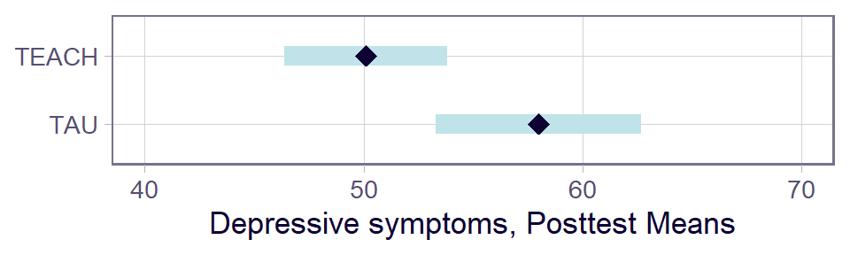

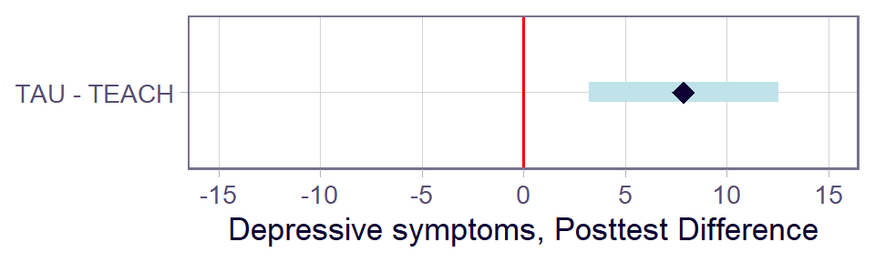

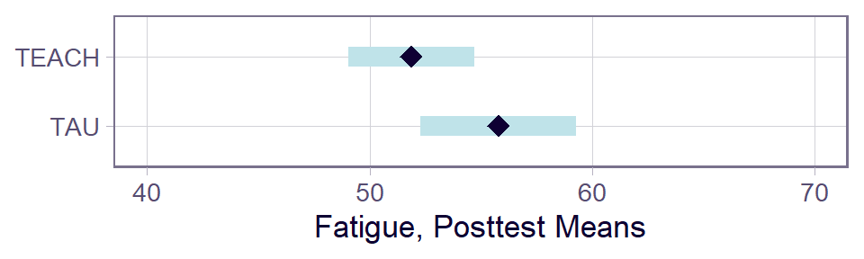

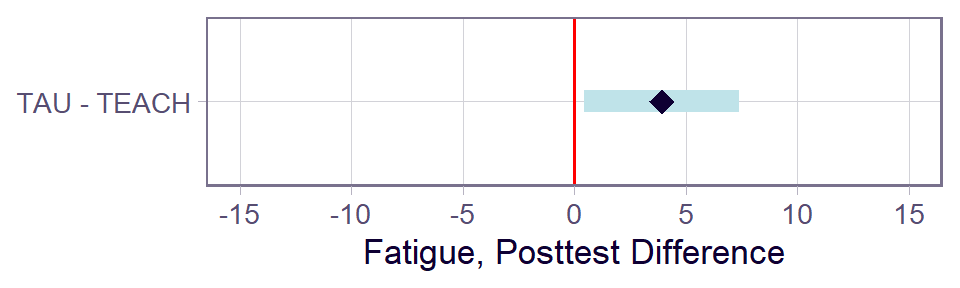

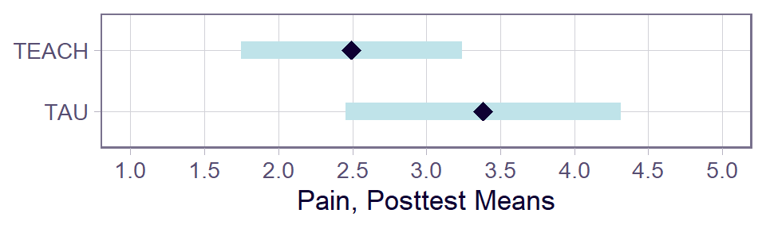

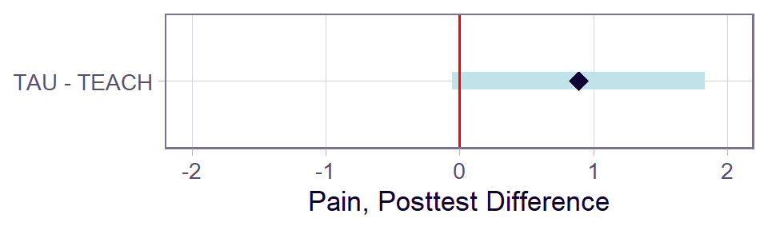

## Fatigue: Arm x Pretest Interaction

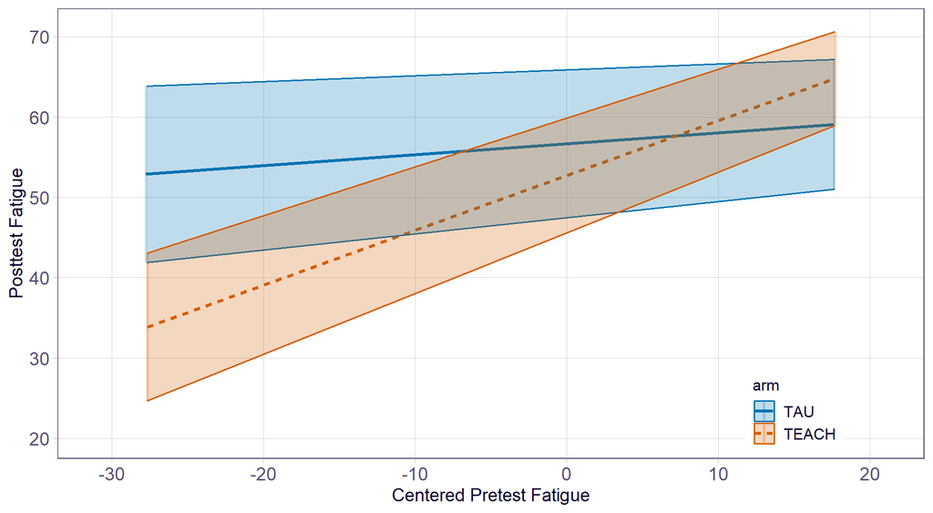

## Exploratory Posttest Outcomes: Arm Main Effect

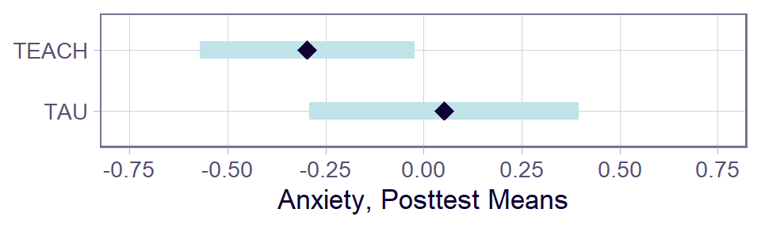

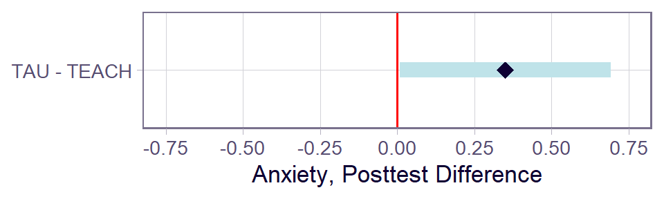

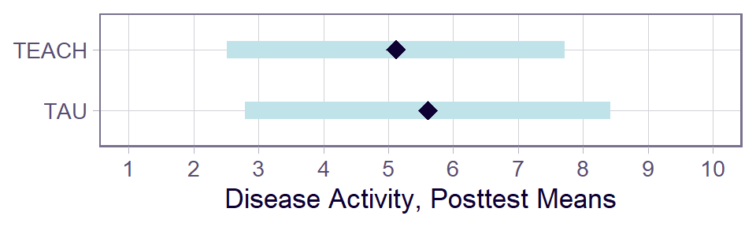

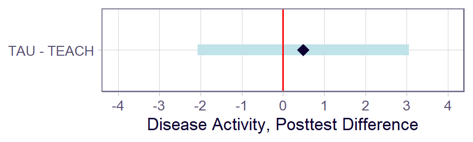

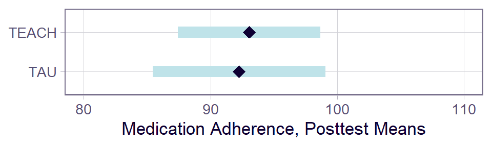

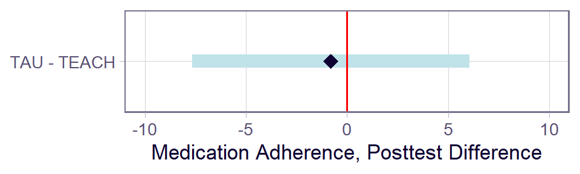

## Medication Adherence: Arm x Pretest Interaction

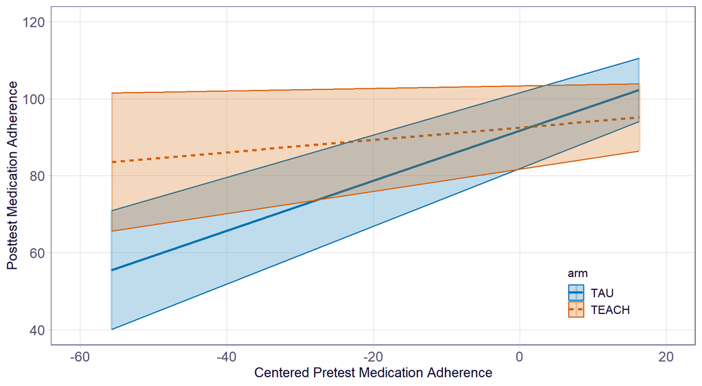

# Conclusions & Discussion

## Limitations

- Small sample limits power & risks reduced representativeness.
- Exclusion criteria limit generalizability.
- TAU practices may vary across sites.
- Self-reported medication adherence could be biased.

## Follow-Up Study Already Underway

- Using a hybrid implementation-effectiveness design.
- Integrates mental health champions into sites to deliver TEACH.
- Patients & caregivers on consumer advocacy team.
- Uses a larger sample.
- Collect posttest & follow-up data 5 times over 56 weeks.

## References

1. Cunningham, N. R., Senger-Carpenter, T., Zuckerman, J., Adler, M., Reid, M. R., Danguecan, A. N., Flores Pereira, L., Mossad, S. I., Ely, S. L., Abulaban, K., Kessler, E. A., Rosenwasser, N., Rubinstein, T. B., Ogbu, E. A., Smitherman, E. A., Miller, A., Abounader, T., Ross, E., Timmerman, L., … Knight, A. (2025). Cognitive behavioral therapy for youth with childhood-onset lupus: A randomized clinical trial [Advance online publication]. *Arthritis Care & Research*. https://doi.org/10.1002/acr.70010

# Questions & Discussion Time

Thank you for attending!